# Class Notes

Tim Riffe

June 19, 2019

Get packages loaded

```r
library(socviz)
library(gapminder)
library(tidyverse)
library(broom)
```

## List columns and nesting

We start off here: https://socviz.co/modeling.html#grouped-analysis-and-list-columns

The objectives are to explain a column type that can hold complex data by using the `map` and `nest` functions. Since statistical model output is a complex list, we will use this column to store that kind of output, and we will send this to `ggplot` to make a nice plot of how the within-continent Preston relationship has changed over time.

```r
# this is a helper function.
fit_ols <- function(df){
    lm(lifeExp ~ log(gdpPercap), data = df)
}

out_le <- gapminder %>%
    group_by(continent, year) %>%
    nest() %>%
    mutate(model = map(data, fit_ols))

out_le
```

```
## # A tibble: 60 x 4
##    continent  year data              model
##    <fct>     <int> <list>            <list>
##  1 Asia       1952 <tibble [33 × 4]> <S3: lm>
##  2 Asia       1957 <tibble [33 × 4]> <S3: lm>
##  3 Asia       1962 <tibble [33 × 4]> <S3: lm>
##  4 Asia       1967 <tibble [33 × 4]> <S3: lm>
##  5 Asia       1972 <tibble [33 × 4]> <S3: lm>
##  6 Asia       1977 <tibble [33 × 4]> <S3: lm>
##  7 Asia       1982 <tibble [33 × 4]> <S3: lm>
##  8 Asia       1987 <tibble [33 × 4]> <S3: lm>
##  9 Asia       1992 <tibble [33 × 4]> <S3: lm>
## 10 Asia       1997 <tibble [33 × 4]> <S3: lm>
## # … with 50 more rows
```

```r
out_tidy <- gapminder %>%
    group_by(continent, year) %>%
    nest() %>%
    mutate(model = map(data, fit_ols),
           tidied = map(model, tidy)) %>%
    unnest(tidied, .drop = TRUE) %>%
    filter(term %nin% "(Intercept)" &
            continent %nin% "Oceania")
sample_n(out_tidy,5)
```

```
## # A tibble: 5 x 7
##   continent  year term           estimate std.error statistic       p.value
##   <fct>     <int> <chr>             <dbl>     <dbl>     <dbl>         <dbl>
## 1 Americas   2002 log(gdpPercap)     5.05     0.844      5.99 0.00000418
## 2 Europe     1987 log(gdpPercap)     4.14     0.752      5.51 0.00000693
## 3 Asia       1992 log(gdpPercap)     5.09     0.649      7.84 0.00000000760
## 4 Europe     2002 log(gdpPercap)     3.74     0.445      8.40 0.00000000391
## 5 Africa     2002 log(gdpPercap)     5.16     1.21       4.25 0.0000920
```

```r
# Note %nin% is similar to !%in%
# take a look!
out_tidy %>% sample_n(5)
```

```
## # A tibble: 5 x 7
##   continent  year term           estimate std.error statistic       p.value
##   <fct>     <int> <chr>             <dbl>     <dbl>     <dbl>         <dbl>
## 1 Africa     1987 log(gdpPercap)     6.48     0.898      7.22 0.00000000275
## 2 Europe     1957 log(gdpPercap)     7.45     0.945      7.88 0.0000000139
## 3 Europe     1987 log(gdpPercap)     4.14     0.752      5.51 0.00000693
## 4 Africa     1977 log(gdpPercap)     4.51     0.920      4.90 0.0000104
## 5 Africa     1967 log(gdpPercap)     3.07     0.988      3.11 0.00313
```

Great, now let’s see how the slope has changed over time:

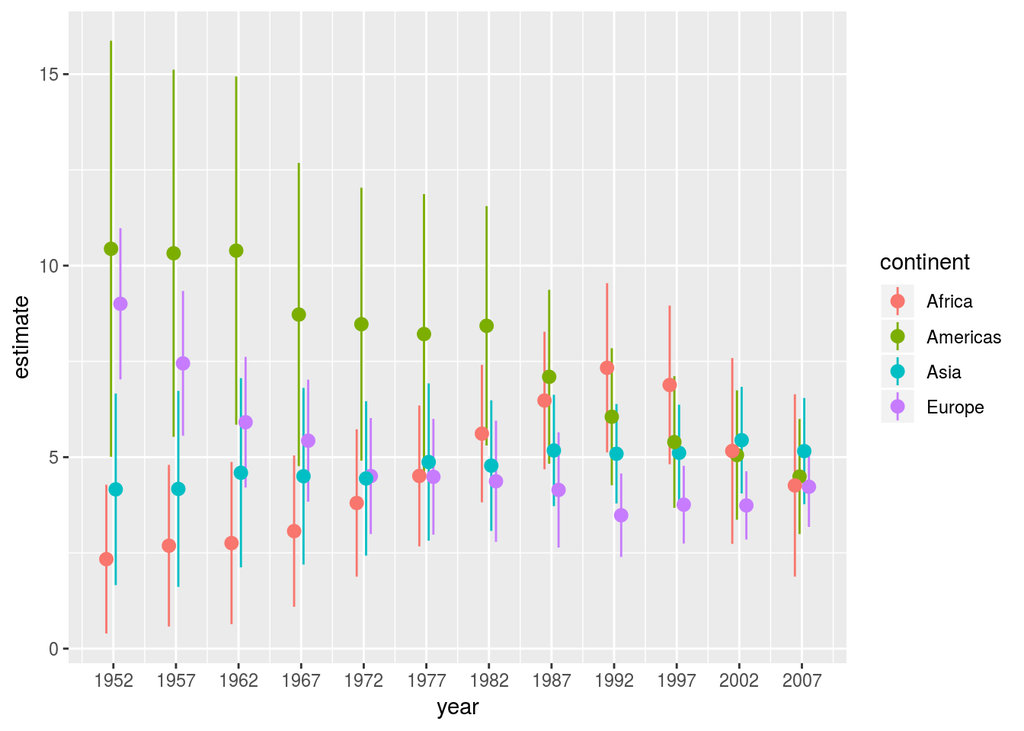

```r
p <- ggplot(data = out_tidy,
            mapping = aes(x = year,
                          y = estimate,
                          ymin = estimate - 2 * std.error,
                          ymax = estimate + 2 * std.error,
                          group = continent, color = continent))
p + geom_pointrange(position = position_dodge(width = 1.5)) +
    scale_x_continuous(breaks = unique(gapminder$year))
```

Timeout for functions!

Toy example, arithmetic

```r
a <- function(x,y){
    b <- x+y * x^2 - y^3
    return(b - y + x)
}

a(x = runif(10), y = runif(10))
```

```
##  [1]  1.0914343  0.7765177  1.5569199 -0.6507268 -0.2075058  0.7918338
##  [7] -1.2328184  0.1676297  0.9130102  0.9369897
```

```r
mx2lx <- function(mx, radix){
    n <- length(mx)
    radix * c(1,exp(-cumsum(mx)))[1:n]
}

lx2dx <- function(lx){
    -diff(c(lx,0))
}

my_lt <- function(mx, radix){
    mx <- tibble(mx)
    lt <- mx %>% mutate(mx = mx,
                  lx = mx2lx(mx, radix = radix),
                  dx = lx2dx(lx))
    lt
}
```

# ggridges

Now we skip a couple chapters and jump to a ridge plot, because we’ll probably want to make one on Thursday using demographic data.

```r
library(ggridges)
```

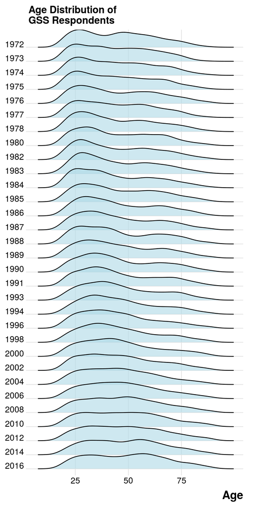

```r
p <- ggplot(gss_lon,
            mapping = aes(x = age,
                         y = factor(year,
                                   levels = rev(unique(year)),
                                   ordered = TRUE)))

p + geom_density_ridges(alpha = 0.6, fill = "lightblue", scale = 1.5) +
    scale_x_continuous(breaks = c(25,50,75)) +
    scale_y_discrete(expand = c(0.01,0)) +
    labs(x = "Age", y = NULL, title = "Age Distribution of \nGSS Respondents") +
    theme_ridges() +
    theme(title = element_text(size = 16, face = "bold"))
```

# Exercise for Thursday:

This is a challenge. Are you up to it?

Get HFC ASFR data from here: https://www.fertilitydata.org/cgi-bin/data.php

Click on the one called *All HFC data (6.8Mb)* to get the big zip file.

Then follow these steps:

1. move it to the folder for today’s session
2. read it into `R` somehow.
3. examine the dataset using `sample_n()` to get a feel for it.
4. within each subset (there arte more grouping variables than just country and year) calculate the total fertility rate (TFR) and the (ASFR-weighted) mean age at childbearing (MAB).
5. now the goal is to draw a ridge plot of ASFR, where each ridge is a discrete bin of TFR in uniform intervals (maybe 8 - 15 different steps or so). Within each ridge there will be two distributions: The ASFR curve with the highest MAB and the one with the lowest MAB.
6. What is the message that this plot delivers?